# Oyster Horseshoe Crab Pilot Project from ENV4800

Liz Suter

Jan 13 2020

### Install and load packages

No need to do any installations in VICE app. Packages should come pre-installed. But need to run libraries:

```r
library(dada2)
library(DECIPHER)
```

### Get sample names- run in Terminal

```bash
cd Raw_data
ls *R1_001.fastq.gz | cut -f 1-2 -d "_" > ../samples
```

### Take a look at the untrimmed reads

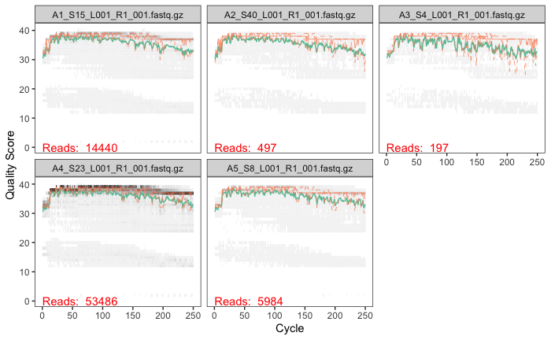

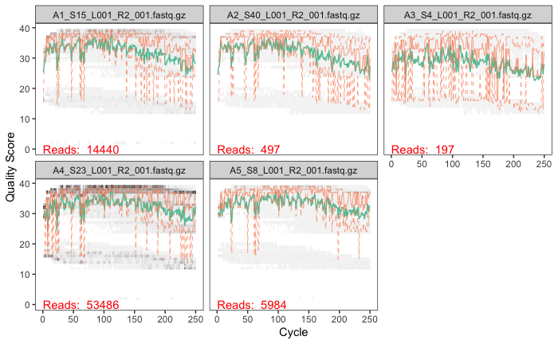

From the above you can see the reads are 250bp and the quality is OK, with the R reads being poorer than the F reads.

### Removing primers using cutadapt- run in Terminal

Sequencing facility told me that the way that they sequence in a way that primers do not get sequenced. Still, check for and remove possible primers

Primers from paper Caporaso et al. 2012: 515f 5’-GTGCCAGCMGCCGCGGTAA-3’ [rev comp: TTACCGCGGCKGCTGGCAC] 806r 5’-GGACTACHVGGGTWTCTAAT-3’ [rev comp: ATTAGAWACCCBDGTAGTCC]

Cut primers with `-b` and `-B` options, which looks for it at both 5’ and 3’ ends. Set the min size to be about 10% smaller than the amplicon length (225). Don’t use the `discard--untrimmed` option, since I don’t want to throw out untrimmed sequences (since these have been removed already by the sequencing setup).

```bash
cd ..
mkdir trimmed_fastq
cd Raw_data

# Run in loop

for sample in $(cat ../samples)
do
    echo "On sample: $sample"
cutadapt -b ATTAGAWACCCBDGTAGTCC \
-b GTGCCAGCMGCCGCGGTAA \
-B TTACCGCGGCKGCTGGCAC \
-B GGACTACHVGGGTWTCTAAT \
-m 225 \
-o ../trimmed_fastq/${sample}_L001_R1_001_trimmed.fastq.gz -p ../trimmed_fastq/${sample}_L001_R2_001_trimmed.fastq.gz \
${sample}_L001_R1_001.fastq.gz ${sample}_L001_R2_001.fastq.gz \
>> ../trimmed_fastq/cutadapt_primer_trimming_stats.txt 2>&1
done
```

Check output stats

```bash
paste ../samples <(grep "passing" ../trimmed_fastq/cutadapt_primer_trimming_stats.txt | cut -f3 -d "(" | tr -d ")") <(grep "filtered" ../trimmed_fastq/cutadapt_primer_trimming_stats.txt | cut -f3 -d "(" | tr -d ")")
```

# DADA2- back to R console

Take a look at the trimmed reads.

```r
forward_reads_trimmed <- paste0("trimmed_fastq/", samples, "_L001_R1_001_trimmed.fastq.gz")
```

```
There were 12 warnings (use warnings() to see them)
```

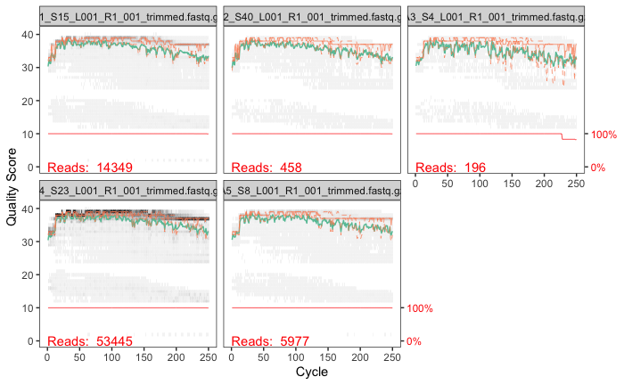

```r
reverse_reads_trimmed <- paste0("trimmed_fastq/", samples, "_L001_R2_001_trimmed.fastq.gz")

# And plot
plotQualityProfile(forward_reads_trimmed[1:5])
```

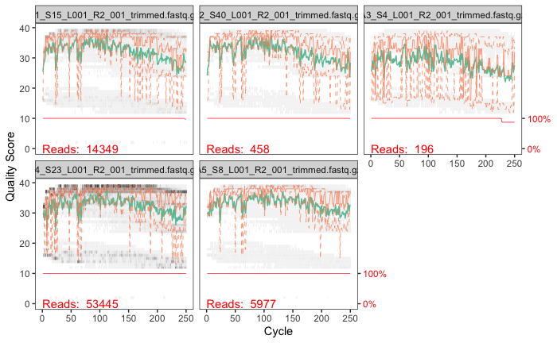

```r
plotQualityProfile(reverse_reads_trimmed[1:5])
```

Comparing the above to the pre-trimmed reads, they look very similar because only very few had primers.

### Quality Trimming

Make a directory for filtered reads

```bash
cd ..
mkdir filtered_fastq
```

Make variables containing the file names for the new filtered forward and reverse reads that we will make

```r
filtered_forward_reads <- paste0("filtered_fastq/",samples, "_L001_R1_001_filtered.fastq.gz")
filtered_reverse_reads <- paste0("filtered_fastq/",samples, "_L001_R2_001_filtered.fastq.gz")
```

```r
filtered_out <- filterAndTrim(forward_reads_trimmed, filtered_forward_reads,
                reverse_reads_trimmed, filtered_reverse_reads, maxEE=c(2,2),
                rm.phix=TRUE, minLen=150, truncLen=c(225,175), truncQ = 2, maxN=0)
```

Check out the quality profiles again.

```r
filtered_out
```

```
                                    reads.in reads.out
A1_S15_L001_R1_001_trimmed.fastq.gz    14349     12520
A2_S40_L001_R1_001_trimmed.fastq.gz      458       411
A3_S4_L001_R1_001_trimmed.fastq.gz       196       126
A4_S23_L001_R1_001_trimmed.fastq.gz    53445     47460
A5_S8_L001_R1_001_trimmed.fastq.gz      5977      5295
B1_S14_L001_R1_001_trimmed.fastq.gz    13942     12299
B2_S30_L001_R1_001_trimmed.fastq.gz      417       366
B3_S33_L001_R1_001_trimmed.fastq.gz      567       465
B4_S28_L001_R1_001_trimmed.fastq.gz    56009     50572
B5_S5_L001_R1_001_trimmed.fastq.gz      6061      5391
C1_S38_L001_R1_001_trimmed.fastq.gz    15916     13694
C2_S26_L001_R1_001_trimmed.fastq.gz      964       856
C3_S24_L001_R1_001_trimmed.fastq.gz      137        83
C4_S37_L001_R1_001_trimmed.fastq.gz    48116     43229
C5_S32_L001_R1_001_trimmed.fastq.gz     7756      6864
D1_S19_L001_R1_001_trimmed.fastq.gz    18390     15961
D2_S13_L001_R1_001_trimmed.fastq.gz      753       645
D3_S34_L001_R1_001_trimmed.fastq.gz      320       222
D4_S20_L001_R1_001_trimmed.fastq.gz    44606     39959
D5_S27_L001_R1_001_trimmed.fastq.gz    10938      9748
E1_S39_L001_R1_001_trimmed.fastq.gz     3552      3021
E2_S18_L001_R1_001_trimmed.fastq.gz       34        18
E3_S11_L001_R1_001_trimmed.fastq.gz    59171     53942
E4_S25_L001_R1_001_trimmed.fastq.gz      780       426
E5_S2_L001_R1_001_trimmed.fastq.gz     61440     56224
F1_S16_L001_R1_001_trimmed.fastq.gz     6153      5266
F2_S31_L001_R1_001_trimmed.fastq.gz      100        87
F3_S6_L001_R1_001_trimmed.fastq.gz     51136     46112
F4_S21_L001_R1_001_trimmed.fastq.gz      704       396
F5_S3_L001_R1_001_trimmed.fastq.gz     61899     55726
G1_S10_L001_R1_001_trimmed.fastq.gz     3172      2727
G2_S29_L001_R1_001_trimmed.fastq.gz      138       123
G3_S35_L001_R1_001_trimmed.fastq.gz       89        66
G4_S1_L001_R1_001_trimmed.fastq.gz       232       155
G5_S12_L001_R1_001_trimmed.fastq.gz    28980     26049
H1_S9_L001_R1_001_trimmed.fastq.gz      3702      3118
H2_S36_L001_R1_001_trimmed.fastq.gz      210       167
H3_S17_L001_R1_001_trimmed.fastq.gz       86        47
H4_S22_L001_R1_001_trimmed.fastq.gz      361       194
H5_S7_L001_R1_001_trimmed.fastq.gz     41355     36580
```

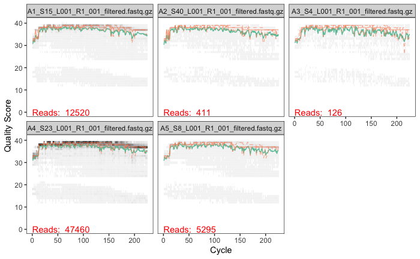

```r
plotQualityProfile(filtered_forward_reads[1:5])
```

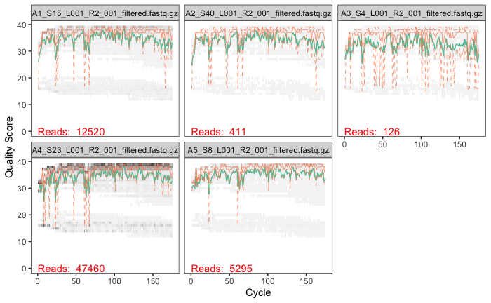

```r
plotQualityProfile(filtered_reverse_reads[1:5])
```

These look a little better but I am still concerned about some of those dips in the R reads

Save workspace up to this point.

### Error profiling

Next, DADA2 tries to learn the error signature of our dataset. This step takes a while

```r
err_forward_reads <- learnErrors(filtered_forward_reads, multithread=TRUE)
```

```
109661400 total bases in 487384 reads from 30 samples will be used for learning the error rates.
```

```r
err_reverse_reads <- learnErrors(filtered_reverse_reads, multithread=TRUE)
```

```
97406750 total bases in 556610 reads from 40 samples will be used for learning the error rates.
```

Plot the error profiles

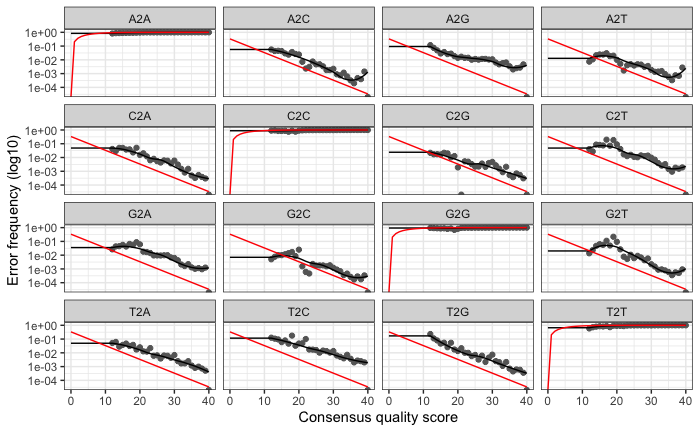

```r
plotErrors(err_forward_reads, nominalQ=TRUE)
```

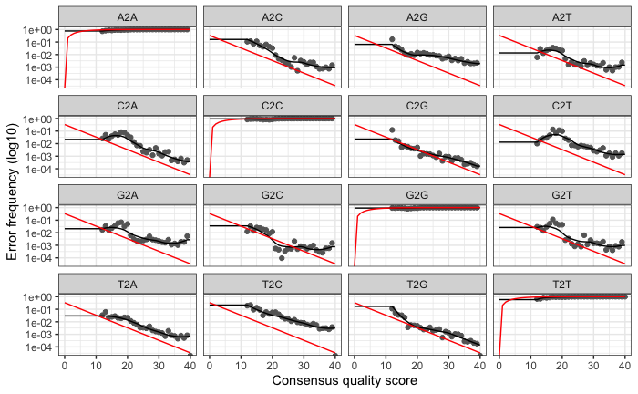

```r
plotErrors(err_reverse_reads, nominalQ=TRUE)
```

The creators of DADA2 describe this [here](https://benjjneb.github.io/dada2/tutorial.html#learn-the-error-rates). The profiles are the error rates for each possible transition in the read (A->C, A->G, etc). Generally in the above plots, you want to see that the black dots (observed error rates for each quality score) match well with the black lines (the estimated error rate). The red line is what is expected based on the quality score.

Backup again since this step above takes awhile Save workspace up to this point.

```r
save.image(file = "backups/upto_errorprofile.RData")
```

### Inferring ASVs

Use the dada command to infer ASVs. We are going to use the pooling option “psuedo” which is described [here](https://benjjneb.github.io/dada2/pseudo.html#Pseudo-pooling). This step also takes awhile

```r
dada_forward <- dada(filtered_forward_reads, err=err_forward_reads, pool="pseudo", multithread=TRUE)
```

```
Sample 1 - 12520 reads in 3301 unique sequences.
Sample 2 - 411 reads in 136 unique sequences.
Sample 3 - 126 reads in 74 unique sequences.
Sample 4 - 47460 reads in 14520 unique sequences.
Sample 5 - 5295 reads in 1600 unique sequences.
Sample 6 - 12299 reads in 3120 unique sequences.
Sample 7 - 366 reads in 128 unique sequences.
Sample 8 - 465 reads in 234 unique sequences.
Sample 9 - 50572 reads in 14897 unique sequences.
Sample 10 - 5391 reads in 1527 unique sequences.
Sample 11 - 13694 reads in 3083 unique sequences.
Sample 12 - 856 reads in 265 unique sequences.
Sample 13 - 83 reads in 66 unique sequences.
Sample 14 - 43229 reads in 10189 unique sequences.
Sample 15 - 6864 reads in 2204 unique sequences.
Sample 16 - 15961 reads in 3397 unique sequences.
Sample 17 - 645 reads in 205 unique sequences.
Sample 18 - 222 reads in 115 unique sequences.
Sample 19 - 39959 reads in 9491 unique sequences.
Sample 20 - 9748 reads in 2915 unique sequences.
Sample 21 - 3021 reads in 861 unique sequences.
Sample 22 - 18 reads in 10 unique sequences.
Sample 23 - 53942 reads in 12144 unique sequences.
Sample 24 - 426 reads in 305 unique sequences.
Sample 25 - 56224 reads in 11344 unique sequences.
Sample 26 - 5266 reads in 1353 unique sequences.
Sample 27 - 87 reads in 35 unique sequences.
Sample 28 - 46112 reads in 10475 unique sequences.
Sample 29 - 396 reads in 309 unique sequences.
Sample 30 - 55726 reads in 11481 unique sequences.
Sample 31 - 2727 reads in 723 unique sequences.
Sample 32 - 123 reads in 43 unique sequences.
Sample 33 - 66 reads in 38 unique sequences.
Sample 34 - 155 reads in 85 unique sequences.
Sample 35 - 26049 reads in 7058 unique sequences.
Sample 36 - 3118 reads in 893 unique sequences.
Sample 37 - 167 reads in 58 unique sequences.
Sample 38 - 47 reads in 36 unique sequences.
Sample 39 - 194 reads in 121 unique sequences.
Sample 40 - 36580 reads in 9111 unique sequences.

   selfConsist step 2
```

```r
dada_reverse <- dada(filtered_reverse_reads, err=err_reverse_reads, pool="pseudo", multithread=TRUE)
```

```
Sample 1 - 12520 reads in 5275 unique sequences.
Sample 2 - 411 reads in 228 unique sequences.
Sample 3 - 126 reads in 101 unique sequences.
Sample 4 - 47460 reads in 22122 unique sequences.
Sample 5 - 5295 reads in 2162 unique sequences.
Sample 6 - 12299 reads in 4760 unique sequences.
Sample 7 - 366 reads in 193 unique sequences.
Sample 8 - 465 reads in 288 unique sequences.
Sample 9 - 50572 reads in 21728 unique sequences.
Sample 10 - 5391 reads in 2001 unique sequences.
Sample 11 - 13694 reads in 5035 unique sequences.
Sample 12 - 856 reads in 426 unique sequences.
Sample 13 - 83 reads in 73 unique sequences.
Sample 14 - 43229 reads in 15794 unique sequences.
Sample 15 - 6864 reads in 3020 unique sequences.
Sample 16 - 15961 reads in 5886 unique sequences.
Sample 17 - 645 reads in 336 unique sequences.
Sample 18 - 222 reads in 152 unique sequences.
Sample 19 - 39959 reads in 15357 unique sequences.
Sample 20 - 9748 reads in 4270 unique sequences.
Sample 21 - 3021 reads in 1306 unique sequences.
Sample 22 - 18 reads in 14 unique sequences.
Sample 23 - 53942 reads in 19020 unique sequences.
Sample 24 - 426 reads in 384 unique sequences.
Sample 25 - 56224 reads in 16987 unique sequences.
Sample 26 - 5266 reads in 2152 unique sequences.
Sample 27 - 87 reads in 51 unique sequences.
Sample 28 - 46112 reads in 17413 unique sequences.
Sample 29 - 396 reads in 372 unique sequences.
Sample 30 - 55726 reads in 18257 unique sequences.
Sample 31 - 2727 reads in 1171 unique sequences.
Sample 32 - 123 reads in 64 unique sequences.
Sample 33 - 66 reads in 40 unique sequences.
Sample 34 - 155 reads in 117 unique sequences.
Sample 35 - 26049 reads in 9819 unique sequences.
Sample 36 - 3118 reads in 1614 unique sequences.
Sample 37 - 167 reads in 107 unique sequences.
Sample 38 - 47 reads in 41 unique sequences.
Sample 39 - 194 reads in 159 unique sequences.
Sample 40 - 36580 reads in 15356 unique sequences.

   selfConsist step 2
```

Backup again

```r
save.image(file = "backups/upto_inferasv.RData")
```